# Презентация по лабораторной работе №4

Эмуляция и измерение задержек в глобальных сетях

Лушин А.А.

Российский университет дружбы народов, Москва, Россия

Факультет Физико-математических и естественных наук

18 февраля 2005

# Информация

## Докладчик

- Лушин Артём Андреевич
- Бакалавр направления компьютерные и информационные науки
- Кафедра теории вероятности и кибербезопасности
- Российский университет дружбы народов
- lusin5745@gmail.com

# Вводная часть

## Цели и задачи

Основной целью работы является знакомство с NETEM - инструментов для тестирования производительности приложений в визуальной сети, а также получение навыков проведения интерактивного и воспроизводимого экспериментов по измерению задержки и её дрожания в моделируемой сети в среде Mininet.

# Ход работы

## Проверка работоспособности сети

Изначально мы провели пингование между двумя хостами. Задержка слишком сильно отличалась и мы установили задержку в 100мс. Затем добавили отклонение задержки в 10мс. Также добавили корреляцию, чтобы посмотреть как именно будет происходит пингование. Также задали нормальное распределение для сети. Провели опыты со всеми настройками и посмотрели как отличается задержка.

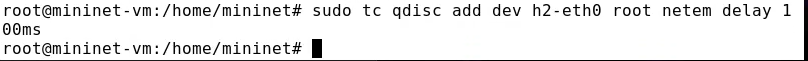

## Работа скрипта

Установили необходимое ПО. Создали скрипты для работы. Создали отдельный скрипт для визуализации. Создали Makefile для запуска скрипта. Посмотрели график, который построил скрипт. Удалили в одном из файлов первую строку и посмотрели на изменённый график. Разработали собственный скрипт для вычисления и провели с ним соответствующие манипуляции, изменяю задержку сети.

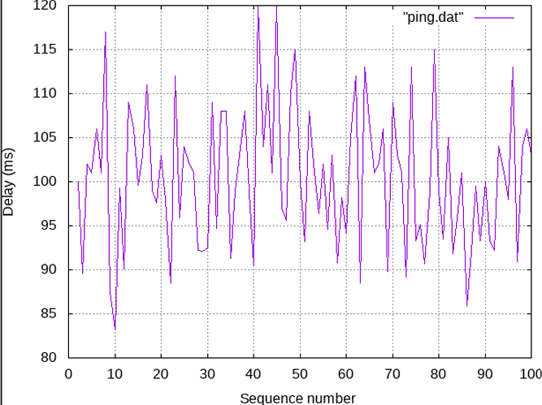

# Результаты

## Вывод

Я познакомился с NETEM - инструментом для тестирования производительности приложений в визуальной сети, а также получил навыки проведения интерактивных и воспроизводимых экспериментов по измерению задержки и её дрожанию в моделируемой сети.